# Risk Factor Analysis

## Outcome Variable

**Outcome Variable:** stunted

## Predictor Variables

**Intervention Variable:** feducyrs

**Adjustment Set:**

- arm
- W_mage
- meducyrs
- hhwealth_quart
- W_mhtcm
- W_mwtkg
- W_mbmi
- W_gagebrth
- W_birthwt
- W_birthlen
- single
- impsan
- delta_W_mage
- delta_meducyrs
- delta_hhwealth_quart
- delta_W_mhtcm
- delta_W_mwtkg
- delta_W_mbmi
- delta_W_gagebrth
- delta_W_birthwt
- delta_W_birthlen
- delta_single
- delta_impsan

## Stratifying Variables

The analysis was stratified on these variable(s):

- agecat
- studyid
- country

## Data Summary

| agecat | studyid | country | feducyrs | stunted | n_cell | n |
| --- | --- | --- | --- | --- | --- | --- |
| Birth | COHORTS | GUATEMALA | High | 0 | 146 | 804 |
| Birth | COHORTS | GUATEMALA | High | 1 | 9 | 804 |
| Birth | COHORTS | GUATEMALA | Low | 0 | 330 | 804 |
| Birth | COHORTS | GUATEMALA | Low | 1 | 25 | 804 |
| Birth | COHORTS | GUATEMALA | Medium | 0 | 280 | 804 |
| Birth | COHORTS | GUATEMALA | Medium | 1 | 14 | 804 |
| Birth | COHORTS | INDIA | High | 0 | 479 | 1354 |
| Birth | COHORTS | INDIA | High | 1 | 48 | 1354 |
| Birth | COHORTS | INDIA | Low | 0 | 392 | 1354 |
| Birth | COHORTS | INDIA | Low | 1 | 47 | 1354 |
| Birth | COHORTS | INDIA | Medium | 0 | 354 | 1354 |
| Birth | COHORTS | INDIA | Medium | 1 | 34 | 1354 |
| Birth | COHORTS | PHILIPPINES | High | 0 | 990 | 2873 |
| Birth | COHORTS | PHILIPPINES | High | 1 | 37 | 2873 |
| Birth | COHORTS | PHILIPPINES | Low | 0 | 758 | 2873 |
| Birth | COHORTS | PHILIPPINES | Low | 1 | 69 | 2873 |
| Birth | COHORTS | PHILIPPINES | Medium | 0 | 952 | 2873 |
| Birth | COHORTS | PHILIPPINES | Medium | 1 | 67 | 2873 |
| Birth | GMS-Nepal | NEPAL | High | 0 | 147 | 694 |
| Birth | GMS-Nepal | NEPAL | High | 1 | 25 | 694 |
| Birth | GMS-Nepal | NEPAL | Low | 0 | 235 | 694 |
| Birth | GMS-Nepal | NEPAL | Low | 1 | 61 | 694 |
| Birth | GMS-Nepal | NEPAL | Medium | 0 | 190 | 694 |
| Birth | GMS-Nepal | NEPAL | Medium | 1 | 36 | 694 |
| Birth | JiVitA-3 | BANGLADESH | High | 0 | 3509 | 21624 |
| Birth | JiVitA-3 | BANGLADESH | High | 1 | 1217 | 21624 |
| Birth | JiVitA-3 | BANGLADESH | Low | 0 | 6170 | 21624 |
| Birth | JiVitA-3 | BANGLADESH | Low | 1 | 3298 | 21624 |
| Birth | JiVitA-3 | BANGLADESH | Medium | 0 | 4854 | 21624 |
| Birth | JiVitA-3 | BANGLADESH | Medium | 1 | 2576 | 21624 |

[output cut: 300 more lines]

The following strata were considered:

- agecat: 24 months, studyid: COHORTS, country: GUATEMALA
- agecat: 24 months, studyid: COHORTS, country: INDIA
- agecat: 24 months, studyid: COHORTS, country: PHILIPPINES
- agecat: 24 months, studyid: GMS-Nepal, country: NEPAL
- agecat: 24 months, studyid: JiVitA-3, country: BANGLADESH
- agecat: 24 months, studyid: JiVitA-4, country: BANGLADESH
- agecat: 24 months, studyid: LCNI-5, country: MALAWI
- agecat: 24 months, studyid: MAL-ED, country: BANGLADESH
- agecat: 24 months, studyid: MAL-ED, country: INDIA
- agecat: 24 months, studyid: MAL-ED, country: NEPAL
- agecat: 24 months, studyid: MAL-ED, country: PERU
- agecat: 24 months, studyid: MAL-ED, country: SOUTH AFRICA
- agecat: 24 months, studyid: MAL-ED, country: TANZANIA, UNITED REPUBLIC OF
- agecat: 24 months, studyid: NIH-Crypto, country: BANGLADESH
- agecat: 24 months, studyid: PROBIT, country: BELARUS
- agecat: 24 months, studyid: PROVIDE, country: BANGLADESH
- agecat: 24 months, studyid: TanzaniaChild2, country: TANZANIA, UNITED REPUBLIC OF
- agecat: 24 months, studyid: ZVITAMBO, country: ZIMBABWE
- agecat: 6 months, studyid: COHORTS, country: GUATEMALA
- agecat: 6 months, studyid: COHORTS, country: INDIA
- agecat: 6 months, studyid: COHORTS, country: PHILIPPINES
- agecat: 6 months, studyid: GMS-Nepal, country: NEPAL
- agecat: 6 months, studyid: JiVitA-3, country: BANGLADESH
- agecat: 6 months, studyid: JiVitA-4, country: BANGLADESH
- agecat: 6 months, studyid: LCNI-5, country: MALAWI
- agecat: 6 months, studyid: MAL-ED, country: BANGLADESH
- agecat: 6 months, studyid: MAL-ED, country: INDIA
- agecat: 6 months, studyid: MAL-ED, country: NEPAL
- agecat: 6 months, studyid: MAL-ED, country: PERU
- agecat: 6 months, studyid: MAL-ED, country: SOUTH AFRICA
- agecat: 6 months, studyid: MAL-ED, country: TANZANIA, UNITED REPUBLIC OF
- agecat: 6 months, studyid: NIH-Crypto, country: BANGLADESH
- agecat: 6 months, studyid: PROBIT, country: BELARUS
- agecat: 6 months, studyid: PROVIDE, country: BANGLADESH
- agecat: 6 months, studyid: SAS-CompFeed, country: INDIA
- agecat: 6 months, studyid: SAS-FoodSuppl, country: INDIA
- agecat: 6 months, studyid: TanzaniaChild2, country: TANZANIA, UNITED REPUBLIC OF
- agecat: 6 months, studyid: ZVITAMBO, country: ZIMBABWE
- agecat: Birth, studyid: COHORTS, country: GUATEMALA
- agecat: Birth, studyid: COHORTS, country: INDIA
- agecat: Birth, studyid: COHORTS, country: PHILIPPINES
- agecat: Birth, studyid: GMS-Nepal, country: NEPAL
- agecat: Birth, studyid: JiVitA-3, country: BANGLADESH
- agecat: Birth, studyid: JiVitA-4, country: BANGLADESH
- agecat: Birth, studyid: MAL-ED, country: BANGLADESH
- agecat: Birth, studyid: MAL-ED, country: INDIA
- agecat: Birth, studyid: MAL-ED, country: NEPAL
- agecat: Birth, studyid: MAL-ED, country: PERU
- agecat: Birth, studyid: MAL-ED, country: SOUTH AFRICA
- agecat: Birth, studyid: MAL-ED, country: TANZANIA, UNITED REPUBLIC OF
- agecat: Birth, studyid: NIH-Crypto, country: BANGLADESH
- agecat: Birth, studyid: PROBIT, country: BELARUS
- agecat: Birth, studyid: PROVIDE, country: BANGLADESH
- agecat: Birth, studyid: SAS-CompFeed, country: INDIA
- agecat: Birth, studyid: ZVITAMBO, country: ZIMBABWE

### Dropped Strata

Some strata were dropped due to rare outcomes:

- agecat: Birth, studyid: MAL-ED, country: INDIA
- agecat: Birth, studyid: MAL-ED, country: NEPAL
- agecat: Birth, studyid: MAL-ED, country: PERU
- agecat: Birth, studyid: MAL-ED, country: SOUTH AFRICA
- agecat: Birth, studyid: MAL-ED, country: TANZANIA, UNITED REPUBLIC OF
- agecat: 6 months, studyid: MAL-ED, country: NEPAL
- agecat: 6 months, studyid: MAL-ED, country: SOUTH AFRICA
- agecat: 24 months, studyid: MAL-ED, country: TANZANIA, UNITED REPUBLIC OF
- agecat: 24 months, studyid: TanzaniaChild2, country: TANZANIA, UNITED REPUBLIC OF

## Methods Detail

We’re interested in the causal parameters $E[Y_a]$ for all values of $a \in \mathcal{A}$. These parameters represent the mean outcome if, possibly contrary to fact, we intervened to set all units to have $A=a$. Under the randomization and positivity assumptions, these are identified by the statistical parameters $\psi_a=E_W[E_{Y|A,W}(Y|A=a,W)]$. In addition, we’re interested in the mean of $Y$, $E[Y]$ under no intervention (the observed mean). We will estimate these parameters by using SuperLearner to fit the relevant likelihood factors – $E_{Y|A,W}(Y|A=a,W)$ and $p(A=a|W)$, and then updating our likelihood fit using a joint TMLE.

For unadjusted analyses ($W=\{\}$), initial likelihoods were estimated using Lrnr_glm to estimate the simple $E(Y|A)$ and Lrnr_mean to estimate $p(A)$. For adjusted analyses, a small library containing Lrnr_glmnet, Lrnr_xgboost, and Lrnr_mean was used.

Having estimated these parameters, we will then use the delta method to estimate relative risks and attributable risks relative to a prespecified baseline level of $A$.

# Results Detail

## Results Plots

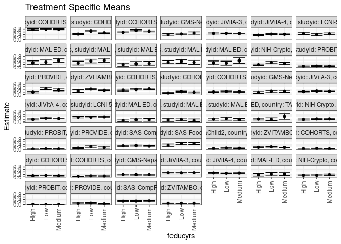

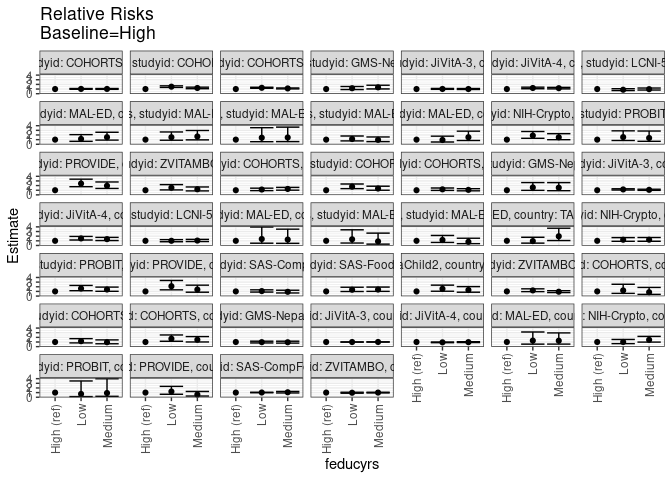

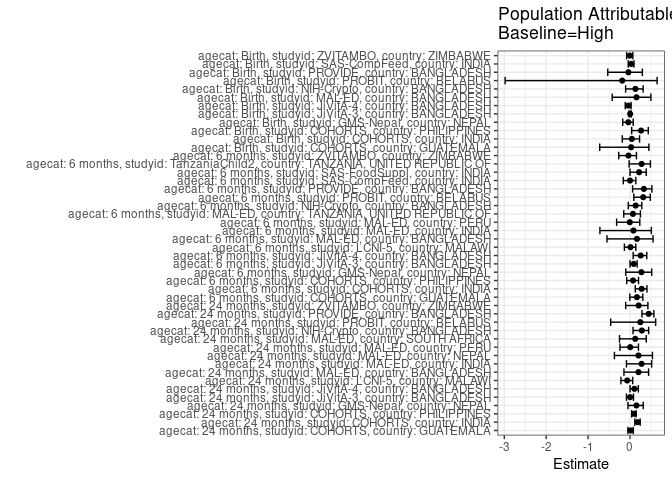

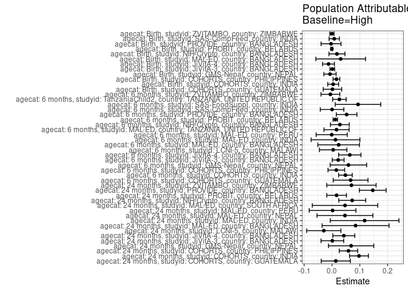

## Results Table

### Parameter: TSM

| agecat | studyid | country | intervention_level | baseline_level | estimate | ci_lower | ci_upper |
| --- | --- | --- | --- | --- | --- | --- | --- |
| Birth | COHORTS | GUATEMALA | High | NA | 0.0580645 | 0.0212246 | 0.0949044 |
| Birth | COHORTS | GUATEMALA | Low | NA | 0.0704225 | 0.0437906 | 0.0970545 |
| Birth | COHORTS | GUATEMALA | Medium | NA | 0.0476190 | 0.0232611 | 0.0719770 |
| Birth | COHORTS | INDIA | High | NA | 0.0910488 | 0.0664018 | 0.1156958 |
| Birth | COHORTS | INDIA | Low | NA | 0.1071399 | 0.0783111 | 0.1359688 |
| Birth | COHORTS | INDIA | Medium | NA | 0.0867115 | 0.0584280 | 0.1149950 |
| Birth | COHORTS | PHILIPPINES | High | NA | 0.0442642 | 0.0309985 | 0.0575299 |
| Birth | COHORTS | PHILIPPINES | Low | NA | 0.0755518 | 0.0568895 | 0.0942142 |
| Birth | COHORTS | PHILIPPINES | Medium | NA | 0.0656548 | 0.0499450 | 0.0813647 |
| Birth | GMS-Nepal | NEPAL | High | NA | 0.1829630 | 0.1472916 | 0.2186344 |
| Birth | GMS-Nepal | NEPAL | Low | NA | 0.1772068 | 0.1412425 | 0.2131711 |
| Birth | GMS-Nepal | NEPAL | Medium | NA | 0.1736313 | 0.1352683 | 0.2119943 |
| Birth | JiVitA-3 | BANGLADESH | High | NA | 0.3267363 | 0.3154649 | 0.3380076 |
| Birth | JiVitA-3 | BANGLADESH | Low | NA | 0.3247337 | 0.3163519 | 0.3331154 |
| Birth | JiVitA-3 | BANGLADESH | Medium | NA | 0.3286060 | 0.3203128 | 0.3368992 |
| Birth | JiVitA-4 | BANGLADESH | High | NA | 0.3161838 | 0.2876933 | 0.3446742 |
| Birth | JiVitA-4 | BANGLADESH | Low | NA | 0.2931619 | 0.2717633 | 0.3145606 |
| Birth | JiVitA-4 | BANGLADESH | Medium | NA | 0.3067664 | 0.2822170 | 0.3313158 |
| Birth | MAL-ED | BANGLADESH | High | NA | 0.1702128 | 0.0623508 | 0.2780748 |
| Birth | MAL-ED | BANGLADESH | Low | NA | 0.2222222 | 0.0858870 | 0.3585575 |
| Birth | MAL-ED | BANGLADESH | Medium | NA | 0.2173913 | 0.0977303 | 0.3370523 |
| Birth | NIH-Crypto | BANGLADESH | High | NA | 0.1201267 | 0.0845247 | 0.1557287 |
| Birth | NIH-Crypto | BANGLADESH | Low | NA | 0.1200538 | 0.0797707 | 0.1603370 |
| Birth | NIH-Crypto | BANGLADESH | Medium | NA | 0.1763776 | 0.1249935 | 0.2277617 |
| Birth | PROBIT | BELARUS | High | NA | 0.0029140 | -0.0013455 | 0.0071736 |
| Birth | PROBIT | BELARUS | Low | NA | 0.0020677 | 0.0002440 | 0.0038914 |
| Birth | PROBIT | BELARUS | Medium | NA | 0.0026468 | 0.0006929 | 0.0046007 |
| Birth | PROVIDE | BANGLADESH | High | NA | 0.0925078 | 0.0488801 | 0.1361355 |
| Birth | PROVIDE | BANGLADESH | Low | NA | 0.1133888 | 0.0626370 | 0.1641406 |
| Birth | PROVIDE | BANGLADESH | Medium | NA | 0.0530760 | 0.0203269 | 0.0858250 |

[output cut: 108 more lines]

### Parameter: E(Y)

| agecat | studyid | country | intervention_level | baseline_level | estimate | ci_lower | ci_upper |
| --- | --- | --- | --- | --- | --- | --- | --- |
| Birth | COHORTS | GUATEMALA | NA | NA | 0.0597015 | 0.0433139 | 0.0760891 |
| Birth | COHORTS | INDIA | NA | NA | 0.0952733 | 0.0796294 | 0.1109171 |
| Birth | COHORTS | PHILIPPINES | NA | NA | 0.0602158 | 0.0515157 | 0.0689159 |
| Birth | GMS-Nepal | NEPAL | NA | NA | 0.1757925 | 0.1474525 | 0.2041325 |
| Birth | JiVitA-3 | BANGLADESH | NA | NA | 0.3279227 | 0.3204672 | 0.3353781 |
| Birth | JiVitA-4 | BANGLADESH | NA | NA | 0.3036496 | 0.2833035 | 0.3239957 |
| Birth | MAL-ED | BANGLADESH | NA | NA | 0.2015504 | 0.1320546 | 0.2710462 |
| Birth | NIH-Crypto | BANGLADESH | NA | NA | 0.1379781 | 0.1129774 | 0.1629789 |
| Birth | PROBIT | BELARUS | NA | NA | 0.0024583 | 0.0007394 | 0.0041772 |
| Birth | PROVIDE | BANGLADESH | NA | NA | 0.0890538 | 0.0649864 | 0.1131212 |
| Birth | SAS-CompFeed | INDIA | NA | NA | 0.2786229 | 0.2475201 | 0.3097257 |
| Birth | ZVITAMBO | ZIMBABWE | NA | NA | 0.1028072 | 0.0976841 | 0.1079303 |
| 6 months | COHORTS | GUATEMALA | NA | NA | 0.4059735 | 0.3739435 | 0.4380034 |
| 6 months | COHORTS | INDIA | NA | NA | 0.1732852 | 0.1533446 | 0.1932258 |
| 6 months | COHORTS | PHILIPPINES | NA | NA | 0.2113885 | 0.1955816 | 0.2271953 |
| 6 months | GMS-Nepal | NEPAL | NA | NA | 0.2166963 | 0.1826342 | 0.2507583 |
| 6 months | JiVitA-3 | BANGLADESH | NA | NA | 0.2491941 | 0.2409375 | 0.2574508 |
| 6 months | JiVitA-4 | BANGLADESH | NA | NA | 0.2503732 | 0.2360124 | 0.2647340 |
| 6 months | LCNI-5 | MALAWI | NA | NA | 0.3633005 | 0.3301997 | 0.3964012 |
| 6 months | MAL-ED | BANGLADESH | NA | NA | 0.1439394 | 0.0838283 | 0.2040505 |
| 6 months | MAL-ED | INDIA | NA | NA | 0.1521739 | 0.0920273 | 0.2123205 |
| 6 months | MAL-ED | PERU | NA | NA | 0.2053571 | 0.1523375 | 0.2583768 |
| 6 months | MAL-ED | TANZANIA, UNITED REPUBLIC OF | NA | NA | 0.2288557 | 0.1706344 | 0.2870770 |
| 6 months | NIH-Crypto | BANGLADESH | NA | NA | 0.2097902 | 0.1799252 | 0.2396552 |
| 6 months | PROBIT | BELARUS | NA | NA | 0.0380013 | 0.0281677 | 0.0478349 |
| 6 months | PROVIDE | BANGLADESH | NA | NA | 0.1589404 | 0.1297581 | 0.1881227 |
| 6 months | SAS-CompFeed | INDIA | NA | NA | 0.2835709 | 0.2656121 | 0.3015297 |
| 6 months | SAS-FoodSuppl | INDIA | NA | NA | 0.4289474 | 0.3791199 | 0.4787748 |
| 6 months | TanzaniaChild2 | TANZANIA, UNITED REPUBLIC OF | NA | NA | 0.0966303 | 0.0837364 | 0.1095242 |
| 6 months | ZVITAMBO | ZIMBABWE | NA | NA | 0.1611105 | 0.1532617 | 0.1689592 |
| 24 months | COHORTS | GUATEMALA | NA | NA | 0.8084677 | 0.7839679 | 0.8329676 |
| 24 months | COHORTS | INDIA | NA | NA | 0.5347826 | 0.5084567 | 0.5611085 |
| 24 months | COHORTS | PHILIPPINES | NA | NA | 0.6279170 | 0.6082186 | 0.6476154 |
| 24 months | GMS-Nepal | NEPAL | NA | NA | 0.4496920 | 0.4054647 | 0.4939193 |
| 24 months | JiVitA-3 | BANGLADESH | NA | NA | 0.4888460 | 0.4756120 | 0.5020800 |
| 24 months | JiVitA-4 | BANGLADESH | NA | NA | 0.4009526 | 0.3835903 | 0.4183149 |
| 24 months | LCNI-5 | MALAWI | NA | NA | 0.4395797 | 0.3988336 | 0.4803258 |
| 24 months | MAL-ED | BANGLADESH | NA | NA | 0.4188034 | 0.3290222 | 0.5085847 |
| 24 months | MAL-ED | INDIA | NA | NA | 0.4242424 | 0.3396095 | 0.5088753 |
| 24 months | MAL-ED | NEPAL | NA | NA | 0.2307692 | 0.1437242 | 0.3178143 |
| 24 months | MAL-ED | PERU | NA | NA | 0.3841463 | 0.3094772 | 0.4588155 |
| 24 months | MAL-ED | SOUTH AFRICA | NA | NA | 0.3736264 | 0.2736811 | 0.4735717 |
| 24 months | NIH-Crypto | BANGLADESH | NA | NA | 0.2568093 | 0.2190047 | 0.2946140 |
| 24 months | PROBIT | BELARUS | NA | NA | 0.0669563 | 0.0407410 | 0.0931716 |
| 24 months | PROVIDE | BANGLADESH | NA | NA | 0.3287197 | 0.2903909 | 0.3670485 |
| 24 months | ZVITAMBO | ZIMBABWE | NA | NA | 0.3406524 | 0.3173794 | 0.3639255 |

### Parameter: RR

| agecat | studyid | country | intervention_level | baseline_level | estimate | ci_lower | ci_upper |
| --- | --- | --- | --- | --- | --- | --- | --- |
| Birth | COHORTS | GUATEMALA | High | High | 1.0000000 | 1.0000000 | 1.000000 |
| Birth | COHORTS | GUATEMALA | Low | High | 1.2128326 | 0.5794578 | 2.538516 |
| Birth | COHORTS | GUATEMALA | Medium | High | 0.8201058 | 0.3630178 | 1.852729 |
| Birth | COHORTS | INDIA | High | High | 1.0000000 | 1.0000000 | 1.000000 |
| Birth | COHORTS | INDIA | Low | High | 1.1767308 | 0.8038190 | 1.722646 |
| Birth | COHORTS | INDIA | Medium | High | 0.9523630 | 0.6243202 | 1.452773 |
| Birth | COHORTS | PHILIPPINES | High | High | 1.0000000 | 1.0000000 | 1.000000 |
| Birth | COHORTS | PHILIPPINES | Low | High | 1.7068381 | 1.1585097 | 2.514693 |
| Birth | COHORTS | PHILIPPINES | Medium | High | 1.4832484 | 1.0118210 | 2.174323 |
| Birth | GMS-Nepal | NEPAL | High | High | 1.0000000 | 1.0000000 | 1.000000 |
| Birth | GMS-Nepal | NEPAL | Low | High | 0.9685390 | 0.8002333 | 1.172243 |
| Birth | GMS-Nepal | NEPAL | Medium | High | 0.9489968 | 0.7689648 | 1.171178 |
| Birth | JiVitA-3 | BANGLADESH | High | High | 1.0000000 | 1.0000000 | 1.000000 |
| Birth | JiVitA-3 | BANGLADESH | Low | High | 0.9938708 | 0.9642286 | 1.024424 |
| Birth | JiVitA-3 | BANGLADESH | Medium | High | 1.0057223 | 0.9763112 | 1.036020 |
| Birth | JiVitA-4 | BANGLADESH | High | High | 1.0000000 | 1.0000000 | 1.000000 |
| Birth | JiVitA-4 | BANGLADESH | Low | High | 0.9271884 | 0.8546428 | 1.005892 |
| Birth | JiVitA-4 | BANGLADESH | Medium | High | 0.9702156 | 0.8878071 | 1.060273 |
| Birth | MAL-ED | BANGLADESH | High | High | 1.0000000 | 1.0000000 | 1.000000 |
| Birth | MAL-ED | BANGLADESH | Low | High | 1.3055556 | 0.5404307 | 3.153920 |
| Birth | MAL-ED | BANGLADESH | Medium | High | 1.2771739 | 0.5517153 | 2.956548 |
| Birth | NIH-Crypto | BANGLADESH | High | High | 1.0000000 | 1.0000000 | 1.000000 |
| Birth | NIH-Crypto | BANGLADESH | Low | High | 0.9993934 | 0.6452584 | 1.547887 |
| Birth | NIH-Crypto | BANGLADESH | Medium | High | 1.4682629 | 0.9771561 | 2.206194 |
| Birth | PROBIT | BELARUS | High | High | 1.0000000 | 1.0000000 | 1.000000 |
| Birth | PROBIT | BELARUS | Low | High | 0.7095551 | 0.1438641 | 3.499612 |
| Birth | PROBIT | BELARUS | Medium | High | 0.9082989 | 0.2074103 | 3.977655 |
| Birth | PROVIDE | BANGLADESH | High | High | 1.0000000 | 1.0000000 | 1.000000 |
| Birth | PROVIDE | BANGLADESH | Low | High | 1.2257209 | 0.6416730 | 2.341366 |
| Birth | PROVIDE | BANGLADESH | Medium | High | 0.5737456 | 0.2643058 | 1.245467 |

[output cut: 108 more lines]

### Parameter: PAR

| agecat | studyid | country | intervention_level | baseline_level | estimate | ci_lower | ci_upper |
| --- | --- | --- | --- | --- | --- | --- | --- |
| Birth | COHORTS | GUATEMALA | High | NA | 0.0016370 | -0.0315661 | 0.0348400 |
| Birth | COHORTS | INDIA | High | NA | 0.0042245 | -0.0153051 | 0.0237541 |
| Birth | COHORTS | PHILIPPINES | High | NA | 0.0159516 | 0.0038875 | 0.0280157 |
| Birth | GMS-Nepal | NEPAL | High | NA | -0.0071705 | -0.0291360 | 0.0147950 |
| Birth | JiVitA-3 | BANGLADESH | High | NA | 0.0011864 | -0.0072355 | 0.0096082 |
| Birth | JiVitA-4 | BANGLADESH | High | NA | -0.0125341 | -0.0336815 | 0.0086132 |
| Birth | MAL-ED | BANGLADESH | High | NA | 0.0313376 | -0.0580281 | 0.1207034 |
| Birth | NIH-Crypto | BANGLADESH | High | NA | 0.0178515 | -0.0108925 | 0.0465954 |
| Birth | PROBIT | BELARUS | High | NA | -0.0004558 | -0.0040331 | 0.0031216 |
| Birth | PROVIDE | BANGLADESH | High | NA | -0.0034540 | -0.0393273 | 0.0324193 |
| Birth | SAS-CompFeed | INDIA | High | NA | 0.0080881 | -0.0105397 | 0.0267158 |
| Birth | ZVITAMBO | ZIMBABWE | High | NA | -0.0002919 | -0.0078920 | 0.0073083 |
| 6 months | COHORTS | GUATEMALA | High | NA | 0.0670384 | 0.0045131 | 0.1295636 |
| 6 months | COHORTS | INDIA | High | NA | 0.0483222 | 0.0237948 | 0.0728495 |
| 6 months | COHORTS | PHILIPPINES | High | NA | 0.0155411 | -0.0142387 | 0.0453210 |
| 6 months | GMS-Nepal | NEPAL | High | NA | 0.0590056 | -0.0065711 | 0.1245822 |
| 6 months | JiVitA-3 | BANGLADESH | High | NA | 0.0222770 | 0.0011271 | 0.0434269 |
| 6 months | JiVitA-4 | BANGLADESH | High | NA | 0.0640770 | 0.0238811 | 0.1042730 |
| 6 months | LCNI-5 | MALAWI | High | NA | 0.0043092 | -0.0449834 | 0.0536018 |
| 6 months | MAL-ED | BANGLADESH | High | NA | 0.0239394 | -0.0508616 | 0.0987403 |
| 6 months | MAL-ED | INDIA | High | NA | 0.0126390 | -0.0750471 | 0.1003252 |
| 6 months | MAL-ED | PERU | High | NA | -0.0010574 | -0.0571346 | 0.0550198 |
| 6 months | MAL-ED | TANZANIA, UNITED REPUBLIC OF | High | NA | 0.0162573 | -0.0289964 | 0.0615110 |
| 6 months | NIH-Crypto | BANGLADESH | High | NA | 0.0283854 | -0.0054953 | 0.0622661 |
| 6 months | PROBIT | BELARUS | High | NA | 0.0119981 | 0.0039639 | 0.0200322 |
| 6 months | PROVIDE | BANGLADESH | High | NA | 0.0526127 | 0.0155612 | 0.0896642 |
| 6 months | SAS-CompFeed | INDIA | High | NA | 0.0002924 | -0.0421292 | 0.0427141 |
| 6 months | SAS-FoodSuppl | INDIA | High | NA | 0.0934808 | 0.0115742 | 0.1753873 |
| 6 months | TanzaniaChild2 | TANZANIA, UNITED REPUBLIC OF | High | NA | 0.0267184 | 0.0024226 | 0.0510141 |
| 6 months | ZVITAMBO | ZIMBABWE | High | NA | -0.0057915 | -0.0396205 | 0.0280375 |
| 24 months | COHORTS | GUATEMALA | High | NA | 0.0136679 | -0.0386645 | 0.0660002 |
| 24 months | COHORTS | INDIA | High | NA | 0.0969460 | 0.0629813 | 0.1309106 |
| 24 months | COHORTS | PHILIPPINES | High | NA | 0.0592950 | 0.0261254 | 0.0924645 |
| 24 months | GMS-Nepal | NEPAL | High | NA | 0.0688046 | -0.0126404 | 0.1502496 |
| 24 months | JiVitA-3 | BANGLADESH | High | NA | 0.0013468 | -0.0395393 | 0.0422330 |
| 24 months | JiVitA-4 | BANGLADESH | High | NA | 0.0425028 | 0.0030736 | 0.0819321 |
| 24 months | LCNI-5 | MALAWI | High | NA | -0.0294560 | -0.0909907 | 0.0320787 |
| 24 months | MAL-ED | BANGLADESH | High | NA | 0.0848060 | -0.0355732 | 0.2051851 |
| 24 months | MAL-ED | INDIA | High | NA | 0.1172838 | -0.0061978 | 0.2407653 |
| 24 months | MAL-ED | NEPAL | High | NA | 0.0465587 | -0.0539837 | 0.1471012 |
| 24 months | MAL-ED | PERU | High | NA | 0.0021312 | -0.0819927 | 0.0862550 |
| 24 months | MAL-ED | SOUTH AFRICA | High | NA | 0.0468110 | -0.0708143 | 0.1644363 |
| 24 months | NIH-Crypto | BANGLADESH | High | NA | 0.0727060 | 0.0242081 | 0.1212040 |
| 24 months | PROBIT | BELARUS | High | NA | 0.0165778 | -0.0187789 | 0.0519345 |
| 24 months | PROVIDE | BANGLADESH | High | NA | 0.1465864 | 0.0985300 | 0.1946429 |
| 24 months | ZVITAMBO | ZIMBABWE | High | NA | 0.0699328 | -0.0187911 | 0.1586568 |

### Parameter: PAF

| agecat | studyid | country | intervention_level | baseline_level | estimate | ci_lower | ci_upper |
| --- | --- | --- | --- | --- | --- | --- | --- |
| Birth | COHORTS | GUATEMALA | High | NA | 0.0274194 | -0.7228537 | 0.4509614 |
| Birth | COHORTS | INDIA | High | NA | 0.0443405 | -0.1841735 | 0.2287574 |
| Birth | COHORTS | PHILIPPINES | High | NA | 0.2649070 | 0.0406848 | 0.4367214 |
| Birth | GMS-Nepal | NEPAL | High | NA | -0.0407895 | -0.1738239 | 0.0771676 |
| Birth | JiVitA-3 | BANGLADESH | High | NA | 0.0036179 | -0.0223989 | 0.0289726 |
| Birth | JiVitA-4 | BANGLADESH | High | NA | -0.0412783 | -0.1135325 | 0.0262875 |
| Birth | MAL-ED | BANGLADESH | High | NA | 0.1554828 | -0.4245093 | 0.4993299 |
| Birth | NIH-Crypto | BANGLADESH | High | NA | 0.1293789 | -0.1038419 | 0.3133246 |
| Birth | PROBIT | BELARUS | High | NA | -0.1853945 | -2.9796979 | 0.6469179 |
| Birth | PROVIDE | BANGLADESH | High | NA | -0.0387858 | -0.5307422 | 0.2950635 |
| Birth | SAS-CompFeed | INDIA | High | NA | 0.0290287 | -0.0417070 | 0.0949613 |
| Birth | ZVITAMBO | ZIMBABWE | High | NA | -0.0028391 | -0.0795607 | 0.0684302 |
| 6 months | COHORTS | GUATEMALA | High | NA | 0.1651300 | -0.0042920 | 0.3059708 |
| 6 months | COHORTS | INDIA | High | NA | 0.2788591 | 0.1262865 | 0.4047887 |
| 6 months | COHORTS | PHILIPPINES | High | NA | 0.0735193 | -0.0785852 | 0.2041737 |
| 6 months | GMS-Nepal | NEPAL | High | NA | 0.2722962 | -0.1000929 | 0.5186290 |
| 6 months | JiVitA-3 | BANGLADESH | High | NA | 0.0893960 | 0.0005492 | 0.1703446 |
| 6 months | JiVitA-4 | BANGLADESH | High | NA | 0.2559260 | 0.0762946 | 0.4006249 |
| 6 months | LCNI-5 | MALAWI | High | NA | 0.0118612 | -0.1335554 | 0.1386232 |
| 6 months | MAL-ED | BANGLADESH | High | NA | 0.1663158 | -0.5487082 | 0.5512199 |
| 6 months | MAL-ED | INDIA | High | NA | 0.0830565 | -0.7177637 | 0.5105349 |
| 6 months | MAL-ED | PERU | High | NA | -0.0051491 | -0.3189160 | 0.2339733 |
| 6 months | MAL-ED | TANZANIA, UNITED REPUBLIC OF | High | NA | 0.0710373 | -0.1488645 | 0.2488482 |
| 6 months | NIH-Crypto | BANGLADESH | High | NA | 0.1353037 | -0.0409237 | 0.2816959 |
| 6 months | PROBIT | BELARUS | High | NA | 0.3157278 | 0.0919743 | 0.4843445 |
| 6 months | PROVIDE | BANGLADESH | High | NA | 0.3310218 | 0.0623154 | 0.5227267 |
| 6 months | SAS-CompFeed | INDIA | High | NA | 0.0010313 | -0.1603265 | 0.1399502 |
| 6 months | SAS-FoodSuppl | INDIA | High | NA | 0.2179307 | 0.0008942 | 0.3878201 |
| 6 months | TanzaniaChild2 | TANZANIA, UNITED REPUBLIC OF | High | NA | 0.2765010 | -0.0205299 | 0.4870794 |
| 6 months | ZVITAMBO | ZIMBABWE | High | NA | -0.0359473 | -0.2687149 | 0.1541151 |
| 24 months | COHORTS | GUATEMALA | High | NA | 0.0169059 | -0.0500083 | 0.0795558 |
| 24 months | COHORTS | INDIA | High | NA | 0.1812811 | 0.1146741 | 0.2428768 |
| 24 months | COHORTS | PHILIPPINES | High | NA | 0.0944312 | 0.0398800 | 0.1458830 |
| 24 months | GMS-Nepal | NEPAL | High | NA | 0.1530038 | -0.0485739 | 0.3158302 |
| 24 months | JiVitA-3 | BANGLADESH | High | NA | 0.0027551 | -0.0844894 | 0.0829810 |
| 24 months | JiVitA-4 | BANGLADESH | High | NA | 0.1060046 | 0.0021595 | 0.1990425 |
| 24 months | LCNI-5 | MALAWI | High | NA | -0.0670095 | -0.2166836 | 0.0642520 |
| 24 months | MAL-ED | BANGLADESH | High | NA | 0.2024958 | -0.1440331 | 0.4440608 |
| 24 months | MAL-ED | INDIA | High | NA | 0.2764546 | -0.0842774 | 0.5171734 |
| 24 months | MAL-ED | NEPAL | High | NA | 0.2017544 | -0.3717774 | 0.5354960 |
| 24 months | MAL-ED | PERU | High | NA | 0.0055479 | -0.2394685 | 0.2021297 |
| 24 months | MAL-ED | SOUTH AFRICA | High | NA | 0.1252883 | -0.2499330 | 0.3878707 |
| 24 months | NIH-Crypto | BANGLADESH | High | NA | 0.2831129 | 0.0732179 | 0.4454715 |
| 24 months | PROBIT | BELARUS | High | NA | 0.2475918 | -0.4608818 | 0.6124819 |
| 24 months | PROVIDE | BANGLADESH | High | NA | 0.4459313 | 0.2860360 | 0.5700173 |
| 24 months | ZVITAMBO | ZIMBABWE | High | NA | 0.2052909 | -0.1031238 | 0.4274781 |